# How life expectancy change over time for each continent?

Life expectancy for a country is the mean length of life over people of a country. Using variables life expectancy and population of a country:

# 1. derive a formula to compute life expectancy of a continent (a group of countries)

Per un continente “c”, in un dato anno, la formula:

$$\text{lifeExp}_c = \frac{\sum_{i \in c}
\text{lifeExp}_i \cdot \text{pop}_i}{\sum_{i \in c}
\text{pop}_i}$$

ci permette di determinare l’aspettativa di vita di un continente, inteso come gruppo di paesi, dove $\text{lifeExp}_i$ e $\text{pop}_i$, sono l’aspettativa di vita e la popolazione del paese $i$.

L’aspettativa di vita di un paese è la durata media della vita dei suoi abitanti, quindi, il prodotto $\text{lifeExp}_1$ e $\text{pop}_1$ restituisce la somma delle durate di vita delle sue persone. Sommando questo prodotto sui paesi del continente si ottiene la somma delle durate di vita di tutti gli abitanti del continente e poi dividendola per la popolazione totale del continente si ottiene la durata media della vita. Ciò che si ottiene, quindi, è una media delle aspettative di vita dei paesi pesata per la popolazione.

# 2. plot how life expectancy changed over time for each continent

```r
library(tidyverse)
library(gapminder)

by_continent <- gapminder |>
  group_by(continent, year) |>
  summarise(lifeExp = sum(lifeExp * pop) / sum(pop))

by_continent
```

```
## # A tibble: 60 × 3
## # Groups:   continent [5]
##    continent  year lifeExp
##    <fct>     <int>   <dbl>
##  1 Africa     1952    38.8
##  2 Africa     1957    40.9
##  3 Africa     1962    43.1
##  4 Africa     1967    45.2
##  5 Africa     1972    47.2
##  6 Africa     1977    49.2
##  7 Africa     1982    51.0
##  8 Africa     1987    52.8
##  9 Africa     1992    53.4
## 10 Africa     1997    53.3
## # ℹ 50 more rows
```

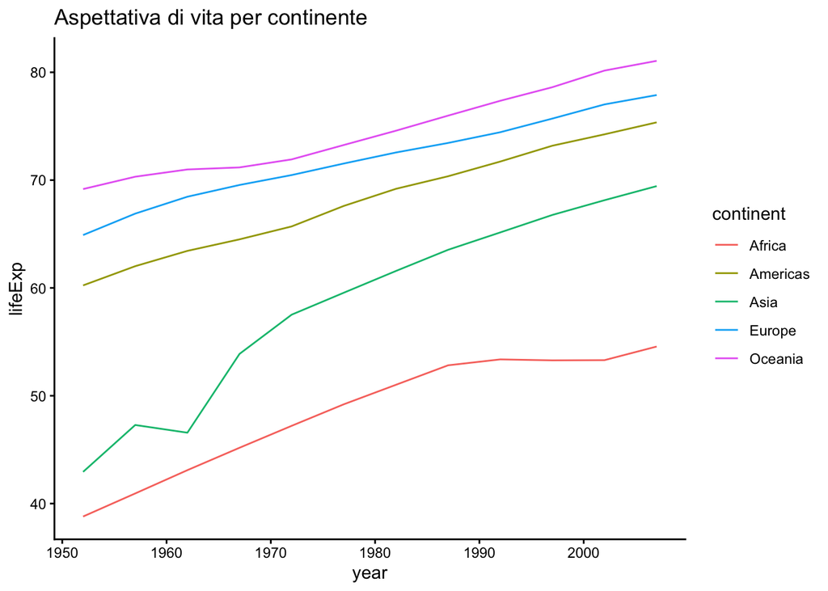

```r
by_continent |>
  ggplot(aes(year, lifeExp, color = continent)) +
  geom_line() +
  ggtitle("Aspettativa di vita per continente") +
  theme_classic()
```

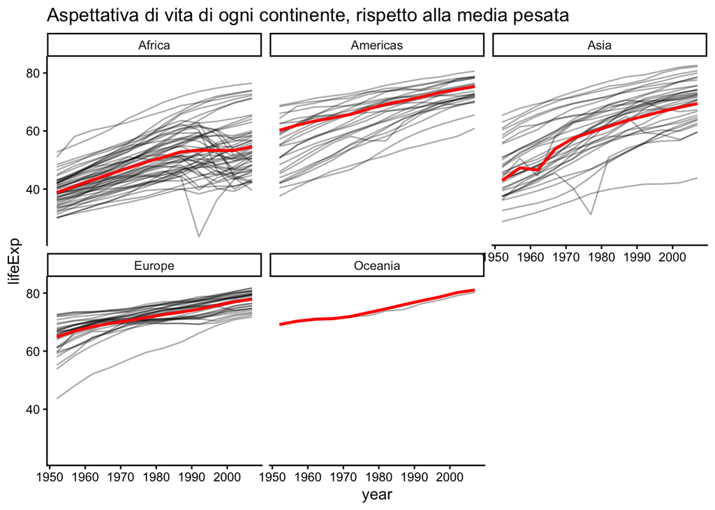

```r
gapminder |>
  ggplot(aes(year, lifeExp)) +
  geom_line(aes(group = country), alpha = 1/3) +
  geom_line(data = by_continent, color = "red", linewidth = 1) +
  facet_wrap(~continent) +
  ggtitle("Aspettativa di vita di ogni continente, rispetto alla media pesata") +
  theme_classic()
```

Il primo grafico mostra che l’aspettativa di vita è cresciuta in tutti i continenti tra il 1952 e il 2007, ma con livelli e andamenti abbastanza diversi. Oceania ed Europa partono da valori più alti, circa 69 e 65 anni, e arrivano a circa 81 e 78 anni. Le Americhe seguono leggermente sotto, passando da circa 60 a 75 anni. Asia e Africa, invece, partono da valori molto più bassi, circa 43 e 39 anni e, nonostante una crescita sostanziale, restano di gran lunga sotto agli altri continenti. L’Asia ha un aumento molto rapido, tuttavia presenta una particolare battuta d’arresto attorno agli anni Sessanta, ma viene seguita poi da una rapida risalita. L’Africa cresce più lentamente e, tra la fine degli anni Ottanta e gli anni Duemila, la crescita si ferma, per poi risalire nel decennio successivo. Si può vedere, quindi, come il divario tra i continenti si sia ridotto per l’Asia, mentre l’Africa resta nettamente indietro.

```r
gapminder |>
  filter(country == "China")
```

```
## # A tibble: 12 × 6
##    country continent  year lifeExp        pop gdpPercap
##    <fct>   <fct>     <int>   <dbl>      <int>     <dbl>
##  1 China   Asia       1952    44    556263527      400.
##  2 China   Asia       1957    50.5  637408000      576.
##  3 China   Asia       1962    44.5  665770000      488.
##  4 China   Asia       1967    58.4  754550000      613.
##  5 China   Asia       1972    63.1  862030000      677.
##  6 China   Asia       1977    64.0  943455000      741.
##  7 China   Asia       1982    65.5 1000281000      962.
##  8 China   Asia       1987    67.3 1084035000     1379.
##  9 China   Asia       1992    68.7 1164970000     1656.
## 10 China   Asia       1997    70.4 1230075000     2289.
## 11 China   Asia       2002    72.0 1280400000     3119.
## 12 China   Asia       2007    73.0 1318683096     4959.
```

# 3. do the same for the whole planet

```r
by_world <- gapminder |>
  group_by(year) |>
  summarise(lifeExp = sum(lifeExp * pop) / sum(pop))

by_world
```

```
## # A tibble: 12 × 2
##     year lifeExp
##    <int>   <dbl>
##  1  1952    48.9
##  2  1957    52.1
##  3  1962    52.3
##  4  1967    57.0
##  5  1972    59.5
##  6  1977    61.2
##  7  1982    62.9
##  8  1987    64.4
##  9  1992    65.6
## 10  1997    66.8
## 11  2002    67.8
## 12  2007    68.9
```

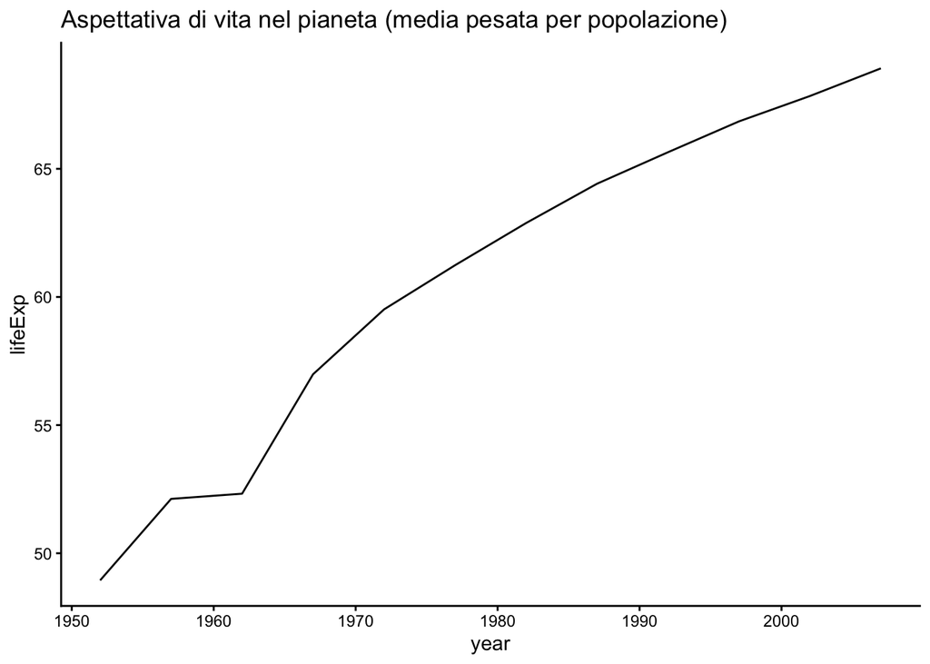

```r
by_world |>
  ggplot(aes(year, lifeExp)) +
  geom_line() +
  ggtitle("Aspettativa di vita nel pianeta (media pesata per popolazione)") +
  theme_classic()
```

Applicando la stessa formula a tutti gli stati del mondo, si ottiene l’aspettativa di vita mondiale, pesata per la popolazione. Il grafico mostra una crescita costante, da circa 50 anni nel 1952 a circa 70 anni nel 2007, tuttavia l’andamento non è regolare, infatti, tra il 1957 e il 1962 la crescita si ferma quasi completamente, per poi riprendere negli anni seguenti. Questa battuta d’arresto riflette il calo della Cina, analizzato in precedenza, che per la sua enorme popolazione incide molto sulla media mondiale. Confrontando questa curva con quella dell’Asia, inoltre, si nota una forte somiglianza tra le due tendenze: entrambe crescono con lo stesso andamento, con la battuta d’arresto attorno ai primi anni Sessanta e la ripresa successiva. L’aspettativa di vita mondiale dipende, quindi, in larga parte da quella asiatica, perché l’Asia ospita la maggior parte della popolazione mondiale e, essendo la media pesata per la popolazione, pesa di più di tutti gli altri continenti. Ciò indica che il miglioramento complessivo dell’aspettativa di vita nel mondo è stato guidato in gran parte dalla crescita dell’Asia, mentre l’Africa, che nel suo ultimo tratto si ferma, ha inciso meno sulla media mondiale.